# Dimension reduction

Package: genstats  
Author: Jeff Leek  
Compilation date: 2015-08-24

### General principles

- Can we find patterns in matrices of data?

### Load some data

We will use this expression set that combines two studies [Transcriptome genetics using second generation sequencing in a Caucasian population.](http://www.ncbi.nlm.nih.gov/pubmed?term=20220756%5Buid%5D) and [Understanding mechanisms underlying human gene expression variation with RNA sequencing.](http://www.ncbi.nlm.nih.gov/pubmed?term=20220758). These studies are different populations but we counted the same genes for both. Then we'll explore the differences.

```r
con =url("http://bowtie-bio.sourceforge.net/recount/ExpressionSets/montpick_eset.RData")
load(file=con)
close(con)
mp = montpick.eset
pdata=pData(mp)
edata=as.data.frame(exprs(mp))
fdata = fData(mp)
ls()
```

```
##  [1] "aa"              "aeid"            "bm"
##  [4] "bodymap.eset"    "chr"             "colramp"
##  [7] "con"             "dend"            "dist1"
## [10] "edata"           "edata_centered"  "edata_centered2"
## [13] "edatay"          "ematrix"         "exp_data"
## [16] "fdata"           "feature_data"    "filt_edata"
## [19] "filt_edata2"     "gene_na"         "hclust1"
## [22] "kmeans1"         "kmeans2"         "low_genes"
## [25] "low_genes2"      "mm"              "montpick.eset"
## [28] "mp"              "pc1"             "pdata"
## [31] "pheno_data"      "sample_na"       "ss"
## [34] "svd1"            "svd2"            "tmp"
## [37] "trop"            "x"
```

### Calculate the singular vectors

Here we calculate the singular vectors:

```r
edata_centered = edata - rowMeans(edata)
svd1 = svd(edata_centered)
names(svd1)
```

```
## [1] "d" "u" "v"
```

### Look at the percent variance explained

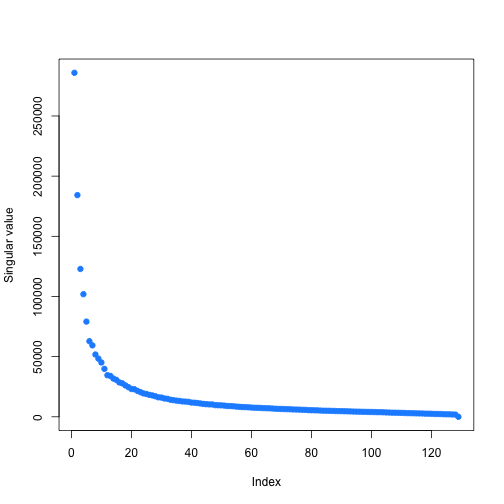

```r
plot(svd1$d,ylab="Singular value",col=2)
```

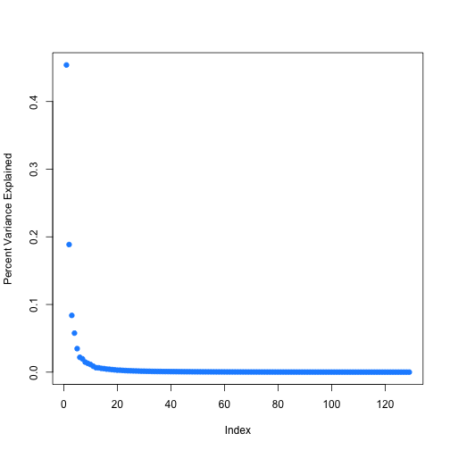

```r
plot(svd1$d^2/sum(svd1$d^2),ylab="Percent Variance Explained",col=2)
```

### Plot top two principal components

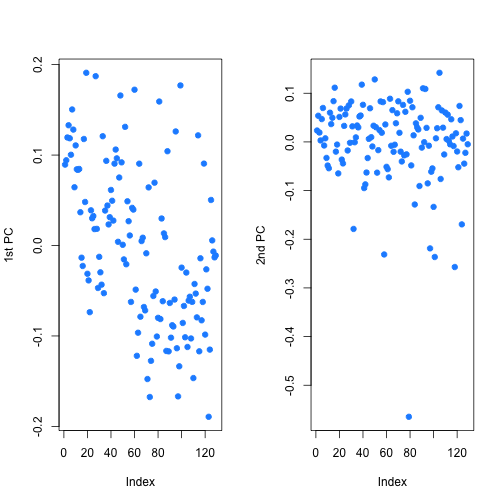

```r
par(mfrow=c(1,2))
plot(svd1$v[,1],col=2,ylab="1st PC")
plot(svd1$v[,2],col=2,ylab="2nd PC")
```

### Plot PC1 vs. PC2

A very common plot is to plot PC1 versus PC2 to see if you can see any “clusters” or “groups”.

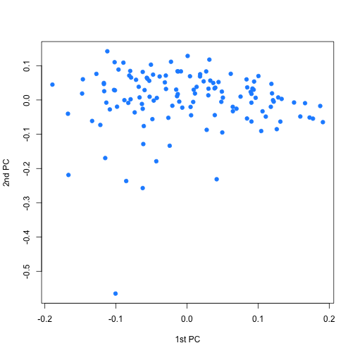

```r
plot(svd1$v[,1],svd1$v[,2],col=2,ylab="2nd PC",xlab="1st PC")
```

One thing you can do is color them by different variables to see if clusters stand out.

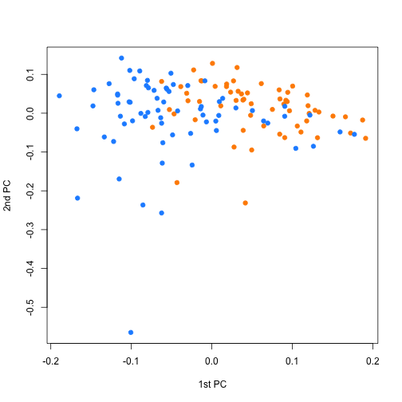

```r
plot(svd1$v[,1],svd1$v[,2],ylab="2nd PC",
     xlab="1st PC",col=as.numeric(pdata$study))
```

Another common plot is to make boxplots comparing the PC for different levels of known covariates (don't forget to show the actual data!).

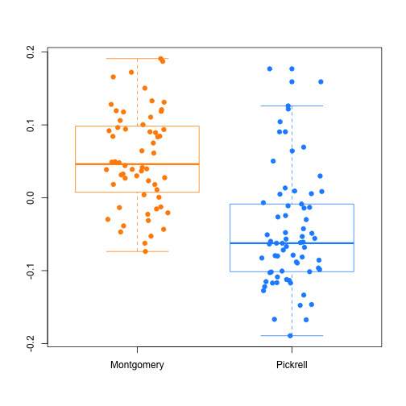

```r
boxplot(svd1$v[,1] ~ pdata$study,border=c(1,2))
points(svd1$v[,1] ~ jitter(as.numeric(pdata$study)),col=as.numeric(pdata$study))
```

### PCs versus SVs

What we have been plotting is not exactly the principal components.

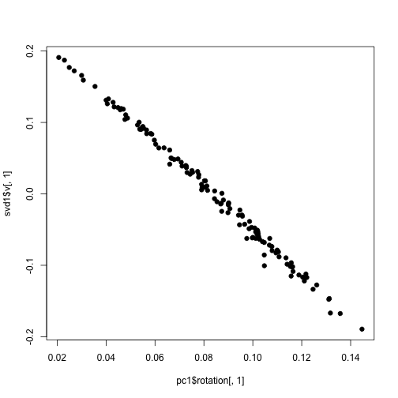

```r
pc1 = prcomp(edata)
plot(pc1$rotation[,1],svd1$v[,1])
```

To get the actual PCs you have to subtract the column means rather than the row means when normalizing.

```r
edata_centered2 = t(t(edata) - colMeans(edata))
svd2 = svd(edata_centered2)
```

Despite this, it is most common for people to perform row-centering and then plot the singular vectors (sometimes labeling them PCs like I have done in this document)

### Dependencies

These are the packages that this tutorial depends on:

- [BiocStyle](http://www.bioconductor.org/packages/release/bioc/html/BiocStyle.html)
- knitr
- RSkittleBrewer
- [Biobase](http://bioconductor.org/packages/release/bioc/html/Biobase.html)
- devtools

```
##  setting  value
##  version  R version 3.2.1 (2015-06-18)
##  system   x86_64, darwin10.8.0
##  ui       RStudio (0.99.447)
##  language (EN)
##  collate  en_US.UTF-8
##  tz       America/New_York
```

```
## Packages ------------------------------------------------------------------
```

```
##  package        * version date
##  AnnotationDbi  * 1.30.1  2015-04-26
##  assertthat       0.1     2013-12-06
##  Biobase        * 2.28.0  2015-04-17
##  BiocGenerics   * 0.14.0  2015-04-17
##  BiocStyle      * 1.6.0   2015-04-17
##  bitops           1.0-6   2013-08-17
##  caTools          1.17.1  2014-09-10
##  curl             0.9.2   2015-08-08
##  DBI            * 0.3.1   2014-09-24
##  dendextend     * 1.1.0   2015-07-31
##  devtools       * 1.8.0   2015-05-09
##  digest           0.6.8   2014-12-31
##  dplyr          * 0.4.2   2015-06-16
##  evaluate         0.7.2   2015-08-13
##  formatR          1.2     2015-04-21
##  gdata            2.17.0  2015-07-04
##  GenomeInfoDb   * 1.4.2   2015-08-15
##  git2r            0.11.0  2015-08-12
##  gplots         * 2.17.0  2015-05-02
##  gtools           3.5.0   2015-05-29
##  htmltools        0.2.6   2014-09-08
##  IRanges        * 2.2.7   2015-08-09
##  KernSmooth       2.23-15 2015-06-29
##  knitr          * 1.11    2015-08-14
##  lazyeval         0.1.10  2015-01-02
##  magrittr         1.5     2014-11-22
##  markdown         0.7.7   2015-04-22
##  memoise          0.2.1   2014-04-22
##  mime             0.3     2015-03-29
##  org.Hs.eg.db   * 3.1.2   2015-07-17
##  R6               2.1.1   2015-08-19
##  Rcpp             0.12.0  2015-07-25
##  rmarkdown        0.7     2015-06-13
##  RSkittleBrewer * 1.1     2015-07-09
##  RSQLite        * 1.0.0   2014-10-25
##  rstudioapi       0.3.1   2015-04-07
##  rversions        1.0.2   2015-07-13
##  S4Vectors      * 0.6.3   2015-07-31
##  stringi          0.5-5   2015-06-29
```

[output cut: 33 more lines]

```
##  CRAN (R 3.2.0)
##  Bioconductor
##  CRAN (R 3.2.1)
##  CRAN (R 3.2.1)
##  CRAN (R 3.2.1)
##  Github (alyssafrazee/RSkittleBrewer@0a96a20)
##  CRAN (R 3.2.0)
##  CRAN (R 3.2.0)
##  CRAN (R 3.2.1)
##  Bioconductor
##  CRAN (R 3.2.1)
##  CRAN (R 3.2.0)
##  CRAN (R 3.2.0)
##  CRAN (R 3.2.1)
##  CRAN (R 3.2.0)
```